# Vježbe 2 - dio 2

- Ponavljanje perceptron algoritma
- Primjena implementiranog algoritma iz scikit-learn biblioteke

```python
import numpy as np
import pandas as pd
import matplotlib.pyplot as plt
from sklearn import preprocessing
from sklearn.datasets import make_blobs
from sklearn.linear_model import Perceptron

plt.rcParams["figure.figsize"] = (10, 10)
```

- Zadani su podaci $\{x^{(1)}, x^{(2)}, \dots, x^{(m)}\} \subset \mathbb{R}^{n}$ i pripadne oznake/klase $y_i \in \{-1, 1\}$.
- Ideja perceptron algoritma je pronaći **hiperravninu** (potprostor dimenzije $n-1$) takav da se svi podaci s oznakom $1$ nalaze s jedne strane, a ostali s druge strane hiperravnine.
- Hiperravnina je definirana vektorom $\Theta = [\theta_1, \dots, \theta_n]^T \in \mathbb{R}^n$ koji opisuje hiperravninu jednadžbom $$ \Theta^Tx = \theta_1x_1 + \dots + \theta_nx_n = 0. $$
- Ovako definirana hiperravnina očito prolazi kroz ishodište. Hiperravnina koja ne prolazi kroz ishodište ima dodatni *bias* parametar $\theta_0$ (kao i u modelu linearne regresije), a jednadžba postaje $$ \theta_0 + \Theta^Tx = \theta_0 + \theta_1x_1 + \dots + \theta_nx_n = 0. $$
- Za točke $x \in \mathbb{R}^n$ s oznakom 1 (s "gornje" strane hiperravnine) vrijedi $\theta_0 + \Theta{}x > 0$, dok je za ostale $\theta_0 + \Theta{}x < 0$.
- Vektor $\Theta$ je vektor normale na dobivenu hiperravninu.
- U slučaju kad su točke $x^{(i)} \in \mathbb{R}^2$, hiperravnina koju tražimo je **pravac** opisan jednadžbom $$ \theta_0 + \theta_1x + \theta_2y = 0, $$ odnosno $$ y = -\frac{\theta_1}{\theta_2}x - \frac{\theta_0}{\theta_2}, $$ ako je $\theta_2 \neq 0$.

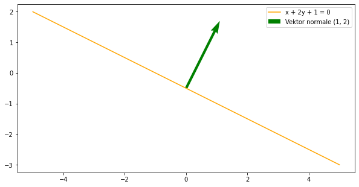

```python
# Pogledajmo slučaj gdje je hiperravnina pravac
theta_0 = 1
theta = np.array([1, 2])

xx = np.linspace(-5, 5, 100)
yy = -xx * (theta[0] / theta[1]) - (theta_0 / theta[1])

plt.plot(xx,yy, color='orange', label='hiperravnina/pravac')
# Sa metodom quiver crtamo 'vektor', tj. duzinu sa strelicom
plt.quiver(0, -0.5,  theta[0],  theta[1], color=['green'], scale=10,  label='theta')

plt.legend(['x + 2y + 1 = 0', 'Vektor normale (1, 2)'])
plt.gca().set_aspect('equal')
plt.show()
```

Linearno separabilne podatke možemo kreirati s funkcijom [sklearn.datasets.make_blobs](https://scikit-learn.org/stable/modules/generated/sklearn.datasets.make_blobs.html).

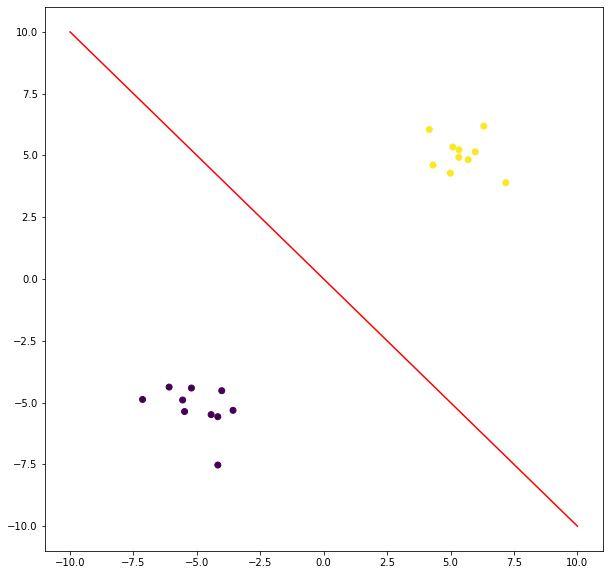

```python
X, y = make_blobs(n_samples=20, n_features=2, centers=[(-5, -5), (5, 5)])
y[y==0] = -1
plt.scatter(X[:,0], X[:,1], c=y)
plt.plot(np.linspace(-10, 10, 100), -np.linspace(-10, 10, 100), color='red')
plt.show()
```

```python
theta = np.array([1, 1])
for i, x in enumerate(X):
    print(f'Točka {x}\nPredikcija: {np.sign(np.dot(theta, x))}\nKlasa:      {y[i]}')
```

```
Točka [5.97536479 5.14502313]
Predikcija: 1.0
Klasa:      1
Točka [-4.4381004  -5.48855548]
Predikcija: -1.0
Klasa:      -1
Točka [-4.17369934 -7.52872663]
Predikcija: -1.0
Klasa:      -1
Točka [-5.56110141 -4.89736754]
Predikcija: -1.0
Klasa:      -1
Točka [6.31169579 6.18757712]
Predikcija: 1.0
Klasa:      1
Točka [5.33366172 5.22618442]
Predikcija: 1.0
Klasa:      1
Točka [-5.48575953 -5.3634511 ]
Predikcija: -1.0
Klasa:      -1
Točka [5.09156808 5.34086247]
Predikcija: 1.0
Klasa:      1
Točka [7.18025199 3.89832246]
Predikcija: 1.0
Klasa:      1
Točka [5.32998744 4.92178728]
Predikcija: 1.0
Klasa:      1
Točka [4.991614   4.28481872]
Predikcija: 1.0
Klasa:      1
Točka [-4.01949978 -4.52034329]
Predikcija: -1.0
Klasa:      -1
Točka [4.16214099 6.04817222]
Predikcija: 1.0
Klasa:      1
Točka [-5.21480143 -4.41257827]
Predikcija: -1.0
Klasa:      -1
Točka [-7.14203898 -4.87506749]
Predikcija: -1.0
Klasa:      -1
Točka [5.69651173 4.82779296]
Predikcija: 1.0
Klasa:      1
Točka [-4.17577917 -5.57207323]
Predikcija: -1.0
Klasa:      -1
Točka [4.30733981 4.61275194]
Predikcija: 1.0
Klasa:      1
Točka [-6.09428598 -4.37350702]
Predikcija: -1.0
Klasa:      -1
Točka [-3.57473871 -5.3157298 ]
Predikcija: -1.0
Klasa:      -1
```

## Zadatak 1

Pomoću perceptrona implementirajte logičke OR, AND, XOR

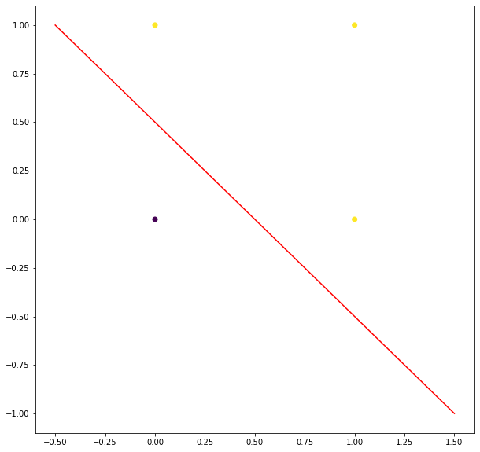

```python
# OR
X = np.array([[0,0],[0,1],[1,0], [1,1]])
y = np.array([-1,1,1,1])

theta_0 = -0.5
theta = np.array([1, 1])
xx = np.linspace(-0.5, 1.5, 100)
yy = -(theta[0] / theta[1]) * xx - theta_0 / theta[1]

plt.scatter(X[:,0], X[:,1], c=y)
plt.plot(xx, yy, color='red')

plt.show()
```

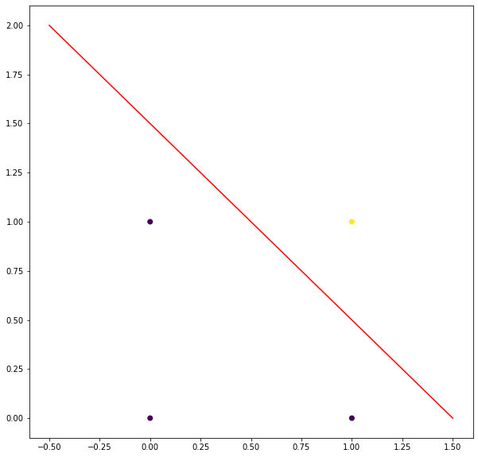

```python
# AND
X = np.array([[0,0],[0,1],[1,0], [1,1]])
y = np.array([-1,-1,-1,1])

theta_0 = -1.5
theta = np.array([1, 1])
xx = np.linspace(-0.5, 1.5, 100)
yy = -(theta[0] / theta[1]) * xx - theta_0 / theta[1]

plt.scatter(X[:,0], X[:,1], c=y)
plt.plot(xx, yy, color='red')

plt.show()
```

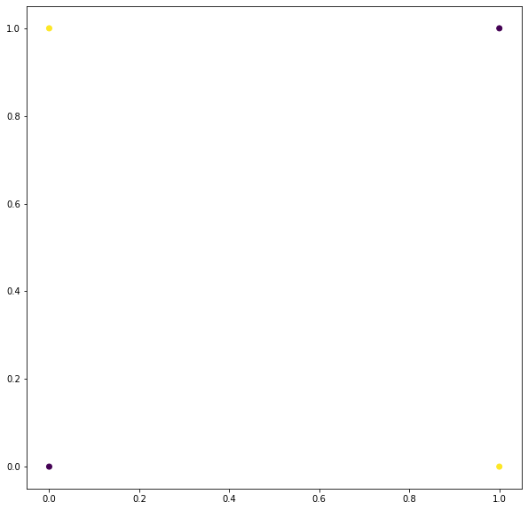

```python
# XOR
X = np.array([[0,0],[0,1],[1,0], [1,1]])
y = np.array([-1,1,1,-1])
plt.scatter(X[:,0], X[:,1], c=y)

plt.show()
```

## Perceptron klasa

- Danas ćemo se upoznati s Perceptron klasom ugrađenom u scikit-learn
- Detalje o klasi možete pronaći u [scikit-learn dokumentaciji](https://scikit-learn.org/stable/modules/generated/sklearn.linear_model.Perceptron.html).
- Za domaću zadaću ćete sami morati implementirati perceptron algoritam

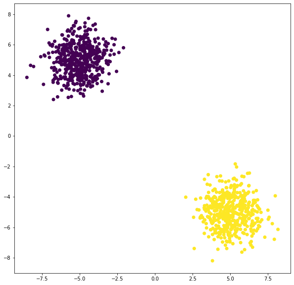

```python
X, y = make_blobs(n_samples=1000, n_features=2, centers=[(-5, 5), (5, -5)])
y[y==0] = -1
plt.scatter(X[:,0], X[:,1], c = y)
plt.show()
```

```python
model = Perceptron(fit_intercept=True)
model.fit(X,y)
model.coef_, model.intercept_
```

```
(array([[ 4.81104922, -3.67473658]]), array([1.]))
```

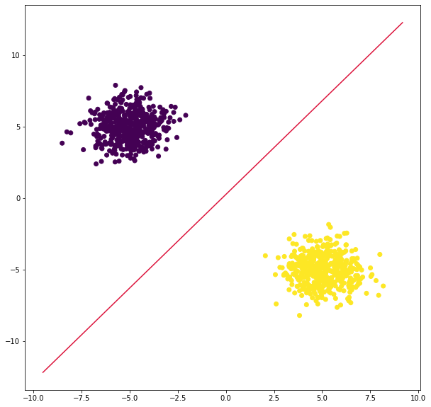

```python
xx = np.linspace(np.min(X)-1, np.max(X)+1, 1000)
yy = -(model.coef_[0][0] / model.coef_[0][1]) * xx - (model.intercept_ / model.coef_[0][1])
plt.scatter(X[:,0], X[:,1], c=y)
plt.plot(xx, yy, color='crimson')
plt.show()
```

Što ako podatke ne možemo separirati pravcem koji prolazi ishodištem?

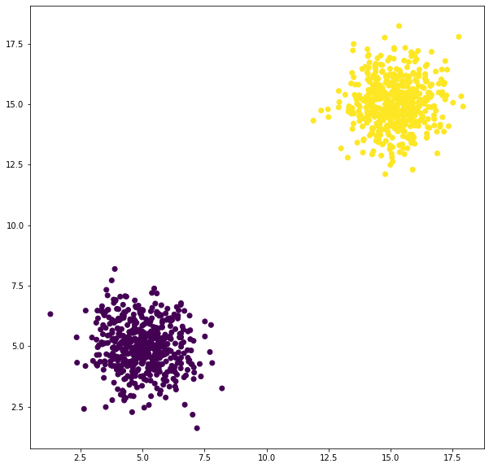

```python
X, y = make_blobs(n_samples=1000, n_features=2, centers=[(5, 5), (15, 15)])
y[y==0] = -1
plt.scatter(X[:,0], X[:,1], c = y)
plt.show()
```

```python
model = Perceptron(fit_intercept=True)
model.fit(X, y)
model.coef_, model.intercept_
model.score(X, y)
```

```
1.0
```

```python
model = Perceptron(fit_intercept=False)
model.fit(X, y)
model.coef_, model.intercept_
model.score(X, y)
```

```
0.499
```

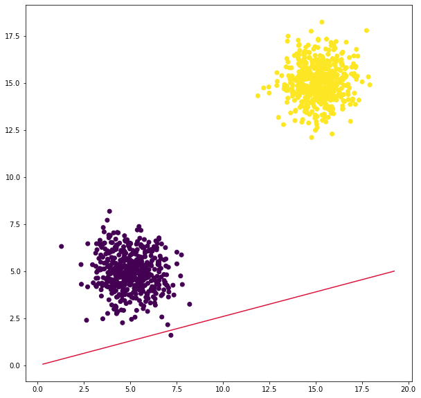

```python
xx = np.linspace(np.min(X)-1, np.max(X)+1, 1000)
yy = -(model.coef_[0][0] / model.coef_[0][1]) * xx - (model.intercept_ / model.coef_[0][1])
plt.scatter(X[:,0], X[:,1], c=y)
plt.plot(xx, yy, color='crimson')
plt.show()
```

Što ako podaci nisu linearno separabilni?

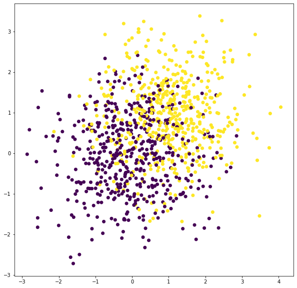

```python
X, y = make_blobs(n_samples=1000, n_features=2, centers=[(0, 0), (1, 1)])
plt.scatter(X[:,0], X[:,1], c=y)
plt.show()
```

```python
model = Perceptron(fit_intercept=True)
model.fit(X, y)
model.coef_, model.intercept_
```

```
(array([[0.06199477, 0.92181677]]), array([-1.]))
```

```python
model.score(X, y)
```

```
0.671
```

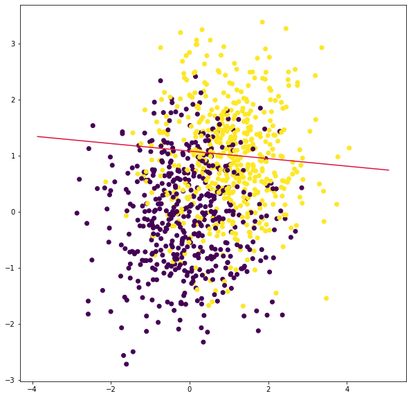

```python
xx = np.linspace(np.min(X)-1, np.max(X)+1, 1000)
yy = -(model.coef_[0][0] / model.coef_[0][1]) * xx - (model.intercept_ / model.coef_[0][1])
plt.scatter(X[:,0], X[:,1], c=y)
plt.plot(xx, yy, color='crimson')
plt.show()
```